# Her2-G3

Cluster Her2-G3

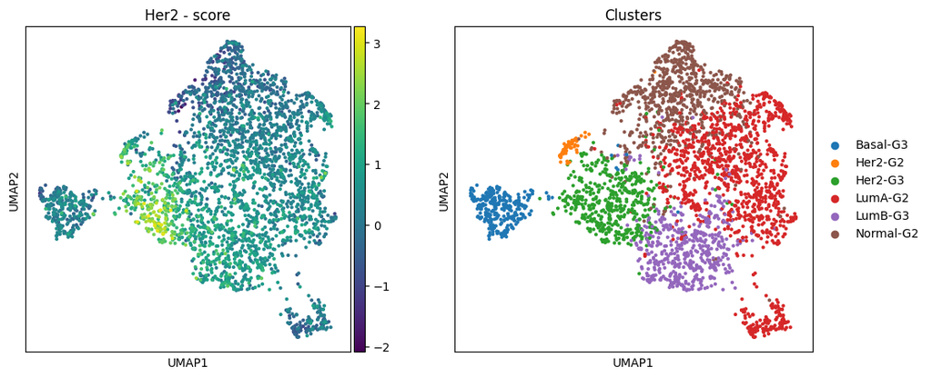

Figure 1: UMAP Visualization of Breast Cancer Samples Colored by Her2 Score and Assigned Clusters.

This figure displays the dimensionality reduction of the breast cancer RNA-Seq samples (from the full cohort) using Uniform Manifold Approximation and Projection (UMAP). Each point in the plots represents an individual sample.

- Left panel: The UMAP space is colored based on a calculated Her2 score for each sample. This score was derived from the expression levels of specific genes from the PAM50 panel known to have high centroid values for the Her2-enriched subtype. The color bar indicates the range of the score, where samples with higher Her2 scores are depicted in yellow/green, and samples with lower scores are in purple/blue.
- Right panel: The same UMAP space is shown, with samples colored according to their assigned cluster. These clusters were previously identified based on the analysis and represent different breast cancer subtypes combined with Nottingham Histologic Grade (G2 or G3): Basal-G3, Her2-G2, Her2-G3, LumA-G2, LumB-G3, and Normal-G2, as indicated by the legend.

Interpretation: The UMAP projection effectively separates the samples into distinct regions corresponding to the different molecular subtypes. The spatial distribution of samples exhibiting high Her2 scores (left panel) shows a strong overlap with the regions occupied by both the Her2-G2 and Her2-G3 clusters (right panel). This visual correspondence confirms that the calculated Her2 score effectively identifies samples with a strong Her2-enriched gene expression signature and validates that the clustering method successfully grouped these samples together based on this molecular characteristic, while further separating them based on histological grade (Her2-G2 vs. Her2-G3) into distinct, though adjacent, regions in the UMAP space.

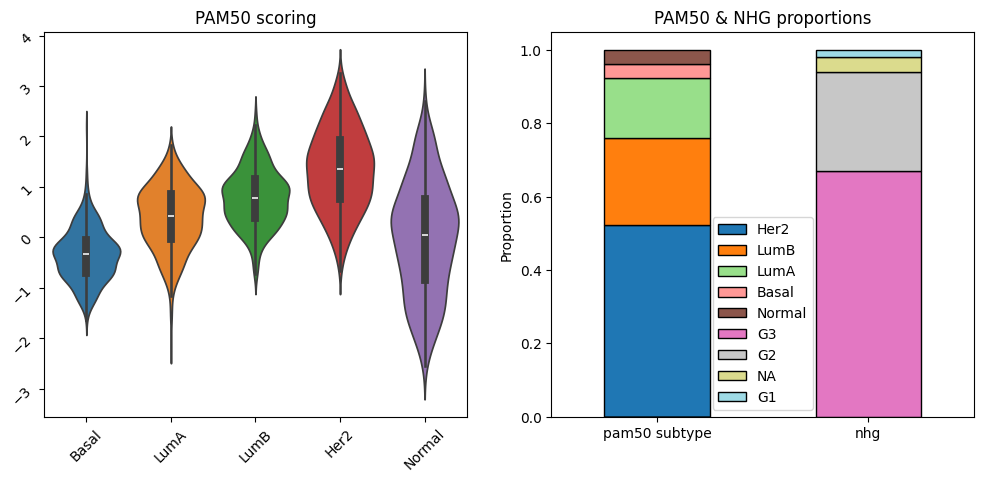

PAM50 scoring - Her2-G3

|  | Basal | LumA | LumB | Her2 | Normal |
| --- | --- | --- | --- | --- | --- |
| count | 478.000000 | 478.000000 | 478.000000 | 478.000000 | 478.000000 |
| mean | -0.344442 | 0.393469 | 0.788659 | 1.348335 | -0.021750 |
| std | 0.521957 | 0.637304 | 0.579495 | 0.803739 | 1.116186 |
| min | -1.630582 | -2.124417 | -0.786511 | -0.657541 | -2.559892 |
| 25% | -0.712601 | -0.038882 | 0.385974 | 0.758701 | -0.849987 |
| 50% | -0.335644 | 0.430704 | 0.779660 | 1.347449 | 0.039916 |
| 75% | -0.055662 | 0.856910 | 1.152855 | 1.935754 | 0.754955 |
| max | 2.200531 | 1.826710 | 2.457598 | 3.261723 | 2.694677 |

PAM50 & NHG proportions Her2-G3

|  | pam50 subtype | nhg |
| --- | --- | --- |
| Her2 | 0.523013 | 0.000000 |
| LumB | 0.236402 | 0.000000 |
| LumA | 0.165272 | 0.000000 |
| Basal | 0.037657 | 0.000000 |
| Normal | 0.037657 | 0.000000 |
| G3 | 0.000000 | 0.669456 |
| G2 | 0.000000 | 0.269874 |
| NA | 0.000000 | 0.041841 |
| G1 | 0.000000 | 0.018828 |

Figure 2: Molecular and Histological Characterization of the Her2-G3 Cluster.

This figure provides a detailed characterization of the samples assigned to the Her2-G3 cluster (n=478) based on PAM50 subtype scoring and clinical Nottingham Histological Grade (NHG).

- Left panel: Violin plots displaying the distribution of PAM50 centroid scores for the samples within the Her2-G3 cluster. Each violin shows the density distribution of how strongly these samples score against the average gene expression profile (centroid) of each of the five intrinsic PAM50 subtypes (Basal-like, Luminal A, Luminal B, Her2-enriched, and Normal-like). Embedded box plots indicate the median and interquartile range. The Y-axis represents the PAM50 score, reflecting the molecular similarity of the Her2-G3 samples to each respective subtype centroid.
- Right panel: Stacked bar plots illustrating the proportions of samples within the Her2-G3 cluster according to their PAM50 molecular subtype assignment (left bar) and their Nottingham Histological Grade (NHG; right bar), based on clinical metadata. The legend specifies the color assigned to each subtype and grade category. This plot visualizes the composition of this specific cluster.

```
2025-07-08 15:04:57,466 [WARNING] Duplicated values found in preranked stats: 14.44% of genes
The order of those genes will be arbitrary, which may produce unexpected results.
```

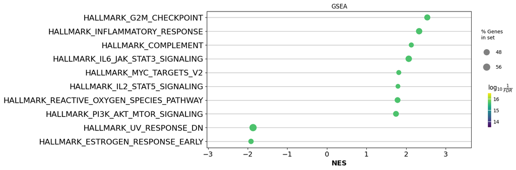

GSEA - Her2-G3

|  | Name | Term | ES | NES | NOM p-val | FDR q-val | FWER p-val | Tag % | Gene % |
| --- | --- | --- | --- | --- | --- | --- | --- | --- | --- |
| 0 | prerank | HALLMARK_INTERFERON_GAMMA_RESPONSE | 0.777005 | 3.077471 | 0.0 | 0.0 | 0.0 | 133/196 | 9.59% |
| 1 | prerank | HALLMARK_ALLOGRAFT_REJECTION | 0.750714 | 3.008545 | 0.0 | 0.0 | 0.0 | 124/195 | 11.91% |
| 2 | prerank | HALLMARK_INTERFERON_ALPHA_RESPONSE | 0.781298 | 2.827875 | 0.0 | 0.0 | 0.0 | 65/95 | 8.79% |
| 3 | prerank | HALLMARK_E2F_TARGETS | 0.6657 | 2.67628 | 0.0 | 0.0 | 0.0 | 117/195 | 13.96% |
| 4 | prerank | HALLMARK_MTORC1_SIGNALING | 0.631933 | 2.553807 | 0.0 | 0.0 | 0.0 | 121/194 | 16.95% |
| 5 | prerank | HALLMARK_G2M_CHECKPOINT | 0.632094 | 2.536571 | 0.0 | 0.0 | 0.0 | 97/189 | 10.03% |
| 6 | prerank | HALLMARK_INFLAMMATORY_RESPONSE | 0.580749 | 2.330628 | 0.0 | 0.0 | 0.0 | 105/197 | 16.10% |
| 7 | prerank | HALLMARK_MYC_TARGETS_V1 | 0.550049 | 2.210505 | 0.0 | 0.0 | 0.0 | 99/193 | 18.94% |
| 8 | prerank | HALLMARK_COMPLEMENT | 0.53827 | 2.133108 | 0.0 | 0.0 | 0.0 | 85/199 | 12.84% |
| 9 | prerank | HALLMARK_IL6_JAK_STAT3_SIGNALING | 0.580515 | 2.068056 | 0.0 | 0.0 | 0.0 | 47/87 | 15.68% |
| 10 | prerank | HALLMARK_ESTROGEN_RESPONSE_EARLY | -0.557514 | -1.916762 | 0.0 | 0.0 | 0.0 | 87/193 | 16.60% |
| 11 | prerank | HALLMARK_UV_RESPONSE_DN | -0.562306 | -1.865281 | 0.0 | 0.0 | 0.0 | 84/138 | 26.87% |
| 12 | prerank | HALLMARK_MYC_TARGETS_V2 | 0.530508 | 1.816625 | 0.0 | 0.0 | 0.0 | 24/57 | 14.83% |
| 13 | prerank | HALLMARK_IL2_STAT5_SIGNALING | 0.447695 | 1.795466 | 0.0 | 0.0 | 0.0 | 78/194 | 14.59% |
| 14 | prerank | HALLMARK_REACTIVE_OXYGEN_SPECIES_PATHWAY | 0.537301 | 1.785779 | 0.0 | 0.0 | 0.0 | 23/47 | 15.20% |
| 15 | prerank | HALLMARK_PI3K_AKT_MTOR_SIGNALING | 0.470591 | 1.746068 | 0.0 | 0.0 | 0.0 | 51/104 | 18.00% |
| 16 | prerank | HALLMARK_TNFA_SIGNALING_VIA_NFKB | 0.394184 | 1.558757 | 0.0 | 0.004564 | 0.02 | 61/197 | 10.67% |
| 17 | prerank | HALLMARK_UV_RESPONSE_UP | 0.393301 | 1.546067 | 0.0 | 0.004707 | 0.022 | 49/154 | 11.68% |
| 18 | prerank | HALLMARK_GLYCOLYSIS | 0.380796 | 1.523536 | 0.0 | 0.005235 | 0.026 | 75/197 | 18.34% |
| 19 | prerank | HALLMARK_KRAS_SIGNALING_UP | 0.377072 | 1.516036 | 0.0 | 0.005135 | 0.027 | 49/194 | 8.66% |
| 20 | prerank | HALLMARK_TGF_BETA_SIGNALING | -0.506471 | -1.507967 | 0.008174 | 0.020727 | 0.126 | 30/54 | 25.30% |
| 21 | prerank | HALLMARK_ESTROGEN_RESPONSE_LATE | -0.419697 | -1.440525 | 0.004635 | 0.034572 | 0.252 | 71/194 | 16.85% |
| 22 | prerank | HALLMARK_UNFOLDED_PROTEIN_RESPONSE | 0.384585 | 1.427869 | 0.0 | 0.013693 | 0.075 | 31/106 | 10.83% |
| 23 | prerank | HALLMARK_OXIDATIVE_PHOSPHORYLATION | 0.351387 | 1.401476 | 0.0 | 0.016602 | 0.095 | 74/184 | 17.61% |
| 26 | prerank | HALLMARK_CHOLESTEROL_HOMEOSTASIS | 0.382057 | 1.316456 | 0.024896 | 0.038959 | 0.21 | 29/73 | 15.31% |

Figure 3: Gene Set Enrichment Analysis (GSEA) Reveals Pathways Associated with Proliferation, Immune Response, and Signaling in the Her2-G3 Cluster.

- X-axis (NES): Normalized Enrichment Score. A positive NES signifies significant enrichment and generally increased gene expression of the pathway in the Her2-G3 cluster compared to the other samples. A negative NES indicates significant enrichment and decreased expression in the Her2-G3 cluster relative to the comparison group.
- Y-axis: The names of the significantly enriched Hallmark gene sets.
- Bubble Size: Represents the percentage of genes within the gene set that are part of the leading edge, meaning they contribute most significantly to the observed enrichment score. Larger bubbles indicate that a higher proportion of the gene set members are driving the enrichment.
- Bubble Color: Indicates the statistical significance of the enrichment result, specifically represented by log10(1/FDR). Higher values (more yellow/green colors) correspond to lower False Discovery Rate (FDR) q-values, denoting higher statistical confidence in the enrichment result. Lower values (purple/blue) indicate less significance.

Interpretation: The GSEA identifies several key biological pathways significantly upregulated (positive NES) in the Her2-G3 cluster. Notably, pathways associated with immune and inflammatory responses, including HALLMARK_INTERFERON_GAMMA_RESPONSE, HALLMARK_ALLOGRAFT_REJECTION, and HALLMARK_INTERFERON_ALPHA_RESPONSE, are among the most highly enriched. Pathways related to cell cycle progression and proliferation such as HALLMARK_E2F_TARGETS and HALLMARK_G2M_CHECKPOINT, along with oncogenic signaling pathways like HALLMARK_MTORC1_SIGNALING and HALLMARK_MYC_TARGETS, also show significant positive enrichment, consistent with the high histological grade (G3) of this cluster. Furthermore, HALLMARK_PI3K_AKT_MTOR_SIGNALING, a central pathway downstream of ERBB2 (Her2) signaling, is significantly enriched. Conversely, pathways related to estrogen signaling, such as HALLMARK_ESTROGEN_RESPONSE_EARLY, are significantly negatively enriched, aligning with the typical hormone receptor-negative status of Her2-enriched cancers. The majority of the displayed enrichments demonstrate high statistical significance, indicated by the yellow/green bubble colors reflecting very low FDR q-values. This figure highlights the proliferative, immune-active, and activated signaling characteristics of the Her2-G3 cluster.